# Final Project of data products

4th of January, 2019

## Final project : Your Reproducible Pitch Presentation

For my final project, I chose to do a quick app to display the impact of different variables on the quality of a red wine.

The dataset can be found at the UCI repository

As I needed to implement reactive expressions to apply the filters dynamically, I did not feel the need to implement a predictive model as it is not the objective of the project.

## Requirements

For the application to run, you'll need the following packages :

- **shiny** : Obviously, to run the application
- **dplyr** : For data manipulation
- **ggplot2** : used with plotly to display the plot
- **plotly** : just for added interactivity, I like the extra information it gives for boxplot
- **corrplot** : for the presentation only, not the slides, for variable selection

## Variable selection

The original dataset has 11 variables + the quality, I'll be selecting the one with the most impact on the quality.

Here is a plot of the correlations :

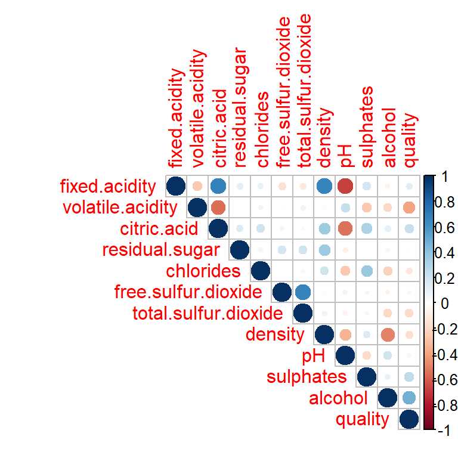

## Quick conclusion

I selected the variables with a coefficient of correlation superior to 0.2 or inferior to -0.2

The conclusion was that the volatile acidity, citric acid, sulphates and the alcohol were the variables with the most impact on the quality.

The application display those repartitions, with filters having their default values between the first and the third quartile.